# Project: Identify Customer Segments

In this project, I will apply unsupervised learning techniques to identify segments of the population that form the core customer base for a mail-order sales company in Germany. These segments can then be used to direct marketing campaigns towards audiences that will have the highest expected rate of returns. The data has been provided by Bertelsmann Arvato Analytics, and represents a real-life data science task.

```python
import numpy as np
import pandas as pd
import matplotlib.pyplot as plt
import seaborn as sns
from operator import itemgetter
from sklearn.preprocessing import OneHotEncoder
from sklearn.preprocessing import StandardScaler
from sklearn.preprocessing import Imputer
from sklearn.cluster import KMeans
from sklearn.metrics import silhouette_score
from IdentifyCustomerSegments.data_preparation import Cleaner
from IdentifyCustomerSegments.config import data
from sklearn.decomposition import PCA
import IdentifyCustomerSegments.visuals as visuals
# magic word for producing visualizations in notebook
%matplotlib inline
import warnings
warnings.filterwarnings('ignore')
```

### Step 0: Load the Data

Each row of the demographics files represents a single person, but also includes information outside of individuals, including information about their household, building, and neighborhood. I will use this information to cluster the general population into groups with similar demographic properties. Then, we will check how the people in the customers dataset fit into those created clusters. The hope here is that certain clusters are over-represented in the customers data, as compared to the general population; those over-represented clusters will be assumed to be part of the core userbase. This information can then be used for further applications, such as targeting for a marketing campaign.

```python
cleaner = Cleaner(data_paths=data)
print(cleaner.azdias.shape)
print(cleaner.customers.shape)
print(cleaner.summary.shape)
```

```
(891221, 85)
(191652, 85)
(85, 4)
```

```python
print(cleaner.azdias.head(4))
```

```
   AGER_TYP  ALTERSKATEGORIE_GROB  ANREDE_KZ  CJT_GESAMTTYP  \
0        -1                     2          1            2.0
1        -1                     1          2            5.0
2        -1                     3          2            3.0
3         2                     4          2            2.0

   FINANZ_MINIMALIST  FINANZ_SPARER  FINANZ_VORSORGER  FINANZ_ANLEGER  \
0                  3              4                 3               5
1                  1              5                 2               5
2                  1              4                 1               2
3                  4              2                 5               2

   FINANZ_UNAUFFAELLIGER  FINANZ_HAUSBAUER    ...     PLZ8_ANTG1  PLZ8_ANTG2  \
0                      5                 3    ...            NaN         NaN
1                      4                 5    ...            2.0         3.0
2                      3                 5    ...            3.0         3.0
3                      1                 2    ...            2.0         2.0

   PLZ8_ANTG3  PLZ8_ANTG4  PLZ8_BAUMAX  PLZ8_HHZ  PLZ8_GBZ  ARBEIT  \
0         NaN         NaN          NaN       NaN       NaN     NaN
1         2.0         1.0          1.0       5.0       4.0     3.0
2         1.0         0.0          1.0       4.0       4.0     3.0
3         2.0         0.0          1.0       3.0       4.0     2.0

   ORTSGR_KLS9  RELAT_AB
0          NaN       NaN
1          5.0       4.0
2          5.0       2.0
3          3.0       3.0

[4 rows x 85 columns]
```

```python
print(cleaner.summary.head(4))
```

```
              attribute information_level         type missing_or_unknown
0              AGER_TYP            person  categorical             [-1,0]
1  ALTERSKATEGORIE_GROB            person      ordinal           [-1,0,9]
2             ANREDE_KZ            person  categorical             [-1,0]
3         CJT_GESAMTTYP            person  categorical                [0]
```

```python
# Check the structure of the data after it's loaded (e.g. print the number of
# rows and columns, print the first few rows).
all_info = cleaner.azdias.describe()
all_info
```

|  | AGER_TYP | ALTERSKATEGORIE_GROB | ANREDE_KZ | CJT_GESAMTTYP | FINANZ_MINIMALIST | FINANZ_SPARER | FINANZ_VORSORGER | FINANZ_ANLEGER | FINANZ_UNAUFFAELLIGER | FINANZ_HAUSBAUER | ... | PLZ8_ANTG1 | PLZ8_ANTG2 | PLZ8_ANTG3 | PLZ8_ANTG4 | PLZ8_BAUMAX | PLZ8_HHZ | PLZ8_GBZ | ARBEIT | ORTSGR_KLS9 | RELAT_AB |
| --- | --- | --- | --- | --- | --- | --- | --- | --- | --- | --- | --- | --- | --- | --- | --- | --- | --- | --- | --- | --- | --- |
| count | 891221.000000 | 891221.000000 | 891221.000000 | 886367.000000 | 891221.000000 | 891221.000000 | 891221.000000 | 891221.000000 | 891221.000000 | 891221.000000 | ... | 774706.000000 | 774706.000000 | 774706.000000 | 774706.000000 | 774706.000000 | 774706.000000 | 774706.000000 | 794005.000000 | 794005.000000 | 794005.00000 |
| mean | -0.358435 | 2.777398 | 1.522098 | 3.632838 | 3.074528 | 2.821039 | 3.401106 | 3.033328 | 2.874167 | 3.075121 | ... | 2.253330 | 2.801858 | 1.595426 | 0.699166 | 1.943913 | 3.612821 | 3.381087 | 3.167854 | 5.293002 | 3.07222 |
| std | 1.198724 | 1.068775 | 0.499512 | 1.595021 | 1.321055 | 1.464749 | 1.322134 | 1.529603 | 1.486731 | 1.353248 | ... | 0.972008 | 0.920309 | 0.986736 | 0.727137 | 1.459654 | 0.973967 | 1.111598 | 1.002376 | 2.303739 | 1.36298 |
| min | -1.000000 | 1.000000 | 1.000000 | 1.000000 | 1.000000 | 1.000000 | 1.000000 | 1.000000 | 1.000000 | 1.000000 | ... | 0.000000 | 0.000000 | 0.000000 | 0.000000 | 1.000000 | 1.000000 | 1.000000 | 1.000000 | 0.000000 | 1.00000 |
| 25% | -1.000000 | 2.000000 | 1.000000 | 2.000000 | 2.000000 | 1.000000 | 3.000000 | 2.000000 | 2.000000 | 2.000000 | ... | 1.000000 | 2.000000 | 1.000000 | 0.000000 | 1.000000 | 3.000000 | 3.000000 | 3.000000 | 4.000000 | 2.00000 |
| 50% | -1.000000 | 3.000000 | 2.000000 | 4.000000 | 3.000000 | 3.000000 | 3.000000 | 3.000000 | 3.000000 | 3.000000 | ... | 2.000000 | 3.000000 | 2.000000 | 1.000000 | 1.000000 | 4.000000 | 3.000000 | 3.000000 | 5.000000 | 3.00000 |
| 75% | -1.000000 | 4.000000 | 2.000000 | 5.000000 | 4.000000 | 4.000000 | 5.000000 | 5.000000 | 4.000000 | 4.000000 | ... | 3.000000 | 3.000000 | 2.000000 | 1.000000 | 3.000000 | 4.000000 | 4.000000 | 4.000000 | 7.000000 | 4.00000 |
| max | 3.000000 | 9.000000 | 2.000000 | 6.000000 | 5.000000 | 5.000000 | 5.000000 | 5.000000 | 5.000000 | 5.000000 | ... | 4.000000 | 4.000000 | 3.000000 | 2.000000 | 5.000000 | 5.000000 | 5.000000 | 9.000000 | 9.000000 | 9.00000 |

8 rows × 81 columns

```
[None, None, None, None, None, None, None, None, None, None, None, None]
```

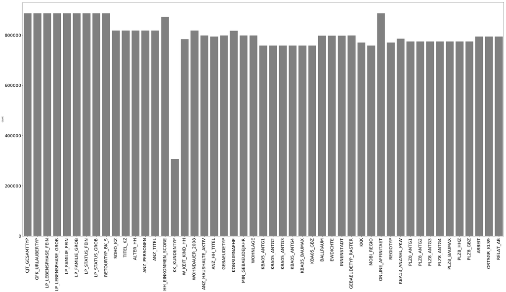

```python
items = cleaner.azdias.shape[0]
features_missing_val = all_info.columns[all_info.loc['count'] < items]
fig = plt.figure(figsize=(40,20))
ax = sns.barplot(x=features_missing_val, y=all_info[features_missing_val].loc['count'], color='grey')
plt.setp(ax.get_xticklabels(), rotation='vertical', fontsize=20)
plt.setp(ax.get_yticklabels(), fontsize=20)
```

I see number of features have some level of inconsistency in terms of amount of rows within. More or less all except one have those values around 800k+ but KK_KUNDENTYP(Consumer pattern over past 12 months) has twice as less as others. Will take a look later. Also worth noting that we have separate file with encoded missing values and the real amount of missing data could the way bigger.

## Step 1: Preprocessing

### Step 1.1: Assess Missing Data

The feature summary file contains a summary of properties for each demographics data column. First of all, lets assess the demographics data in terms of missing data.

#### Step 1.1.1: Convert Missing Value Codes to NaNs

The fourth column of the feature attributes summary (loaded in above as `summary`) documents the codes from the data dictionary that indicate missing or unknown data. While the file encodes this as a list (e.g. `[-1,0]`), this will get read in as a string object.

```python
# Identify missing or unknown data values and convert them to NaNs.
before_cleaning = Cleaner.count_nan_columns(cleaner.azdias)
cleaner.azdias = cleaner.to_nan(cleaner.azdias, cleaner.summary)
after_cleaning = Cleaner.count_nan_columns(cleaner.azdias)
```

#### Step 1.1.2: Assess Missing Data in Each Column

How much missing data is present in each column? There are a few columns that are outliers in terms of the proportion of values that are missing. For the remaining features, are there any patterns in which columns have, or share, missing data?

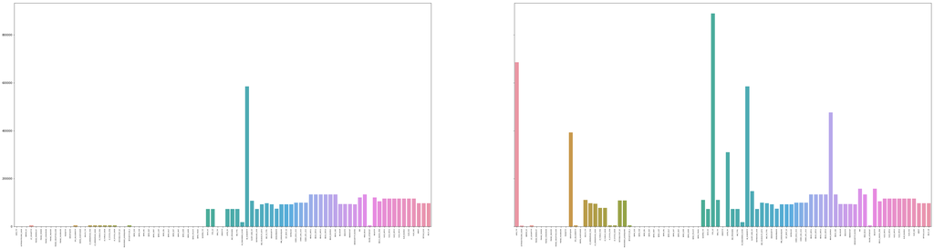

```python
visuals.plot_nans(before=before_cleaning, after=after_cleaning)
```

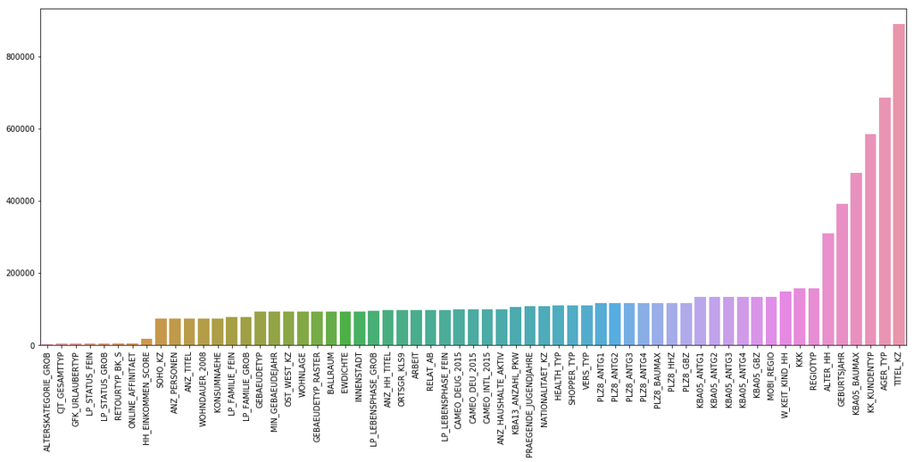

```python
# Investigate patterns in the amount of missing data in each column.
sorted_yielder = cleaner.sort_by_values(dict(after_cleaning))
visuals.plot_bar(list(sorted_yielder))
```

After cleaning we clearly see that there is number of colums which are outliers in terms of missing data. I will be counting feature as outlier if it's missed ~60%(~530k) of data comparing with the size of data set (~890k). That said I would exclude:

- **AGER_TYP** (700k of missing rows)
- **TITEL_KZ** ( > 800k of missing rows)
- **KK_KUNDENTYP** (~550k of missing rows)
- **KBA05_BAUMAX** (~500 of missing rows)

These two below sond pretty important for customers clustering but third of the data in both cases are missing. Will keep them for now and decide later on how to handle it.

- **GEBURTSJAHR** - age (~400k)
- **ALTERHH** - age of head of household. (~350k)

I sorted array by missing rows to see patterns and it is clear that features from close groups have similar number of missing rows. At first glance we could find 6-7 groups sharing same pattern. Those features with similar names and numbers came out from the "master" feature.

I marked those 6 features for dropping but will do that later to make it all at once if during our assessment we will find anything else to drop.

#### Step 1.1.3: Assess Missing Data in Each Row

Now, I'll perform a similar assessment for the rows of the dataset. How much data is missing in each row?

In order to know what to do with the outlier rows, we should see if the distribution of data values on columns that are not missing data (or are missing very little data) are similar or different between the two groups.

If the distributions of non-missing features look similar between the data with many missing values and the data with few or no missing values, then we could argue that simply dropping those points from the analysis won't present a major issue. On the other hand, if the data with many missing values looks very different from the data with few or no missing values, then we should make a note on those data as special.

```python
# How much data is missing in each row of the dataset?
missing_rows = Cleaner.count_nan_rows(cleaner.azdias)
print('min {}, max {}, mean {}'.format(missing_rows.min(), missing_rows.max(),  missing_rows.mean()))
```

```
min 0, max 54, mean 9.396018495973502
```

Average number of missing features in each row ~ 9, when there are rows with 54 absent features which is max seen. I dont think this would be beneficial to use them in analysis. Overall number of features in our data set is 81. Lets look to left and right fromt theretical treshold to see where the possible split could happen.

```python
l, g, less_trh, gr_trh = Cleaner.split_by_treshhold(cleaner.azdias, treshold=34)
cleaner.azdias = l
l.shape, g.shape
```

```
((798054, 85), (93167, 85))
```

We got 81 features and 891221 rows. Of course we want to keep as much data as possible but also we want to have it in a good shape. I will set treshhold the way it doesnt cut more than 15% of data (<100k) but at same time I want to keep rows with huge amount of misssing features out of data set. We saw on the plot above that most of features dont get above 100k of missing rows. Lets try to keep second group around or below 100k of rows.

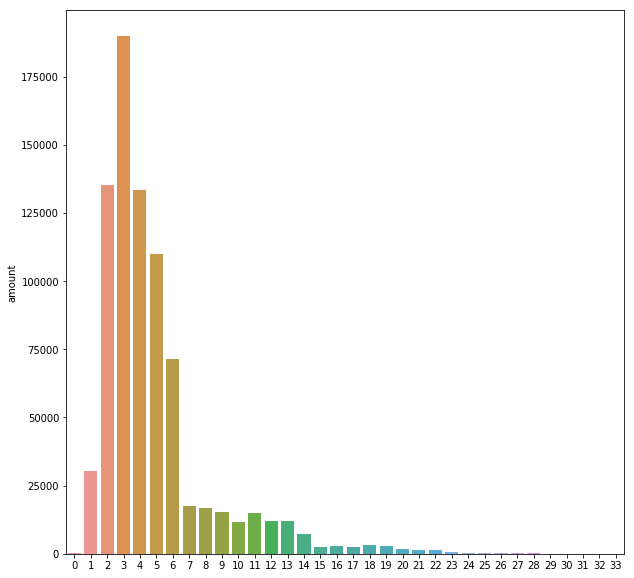

```python
fig, ax = plt.subplots(figsize=(10,10))
sns.barplot(x=less_trh.amount.value_counts().index, y=less_trh.amount.value_counts())
```

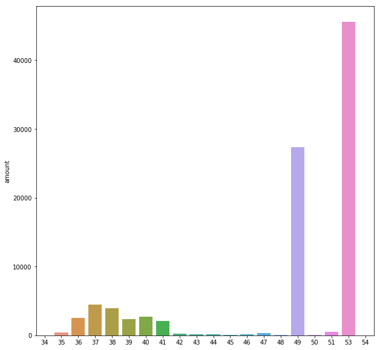

```python
fig, ax = plt.subplots(figsize=(10,10))
sns.barplot(x=gr_trh.amount.value_counts().index, y=gr_trh.amount.value_counts())
```

Amount of missing features over rows getting lower as order grows. At 34 it starts raising. So I cut data based on the plots above with treshold = 34. It doesnt sound like few or no missing rows but I would like to see what happens if keep these rows.

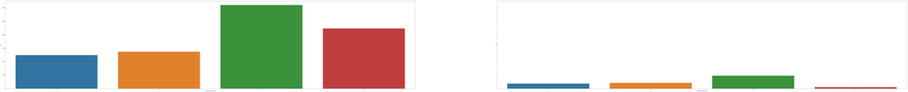

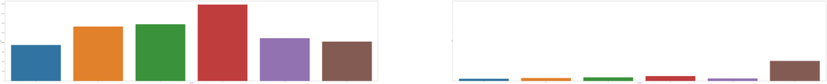

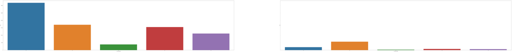

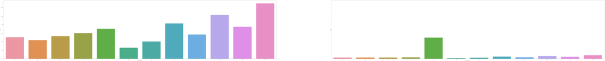

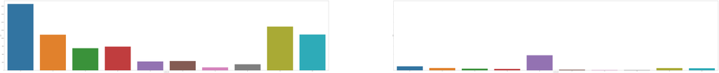

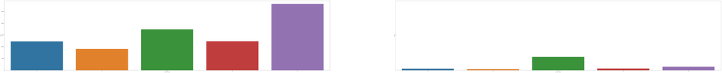

```python
# Compare the distribution of values for at least five columns where there are
# no or few missing values, between the two subsets.

def plot_distr(features, set1, set2):
    for f in features:
        fig, (ax1, ax2) = plt.subplots(ncols=2, figsize=(200,20), sharey=True)
        sns.countplot(x=set1[f], ax=ax1)
        sns.countplot(x=set2[f], ax=ax2)

features=['ALTERSKATEGORIE_GROB', 'CJT_GESAMTTYP','LP_STATUS_GROB','GFK_URLAUBERTYP','LP_STATUS_FEIN', 'RETOURTYP_BK_S']
plot_distr(features, l, g)
```

#### Discussion 1.1.3: Assess Missing Data in Each Row

I split data based on treshold equal to 34. My idea was since we have 81 feature in total I would not want to filter out rows which got more than half of features populated as those could be still valuable. From other hand I dont want to keep noise that only polutes data set. Looking at plot I notice that number of rows with missing features greater than 12 and less than 34 not that big and at worst still carrying more than 47 valuable features. Starting from 34 and beyond missing features noticeably growing and coming to its peak at 53 (almost 50k rows).

Distribution of two groups looks completely different at first glance, so it is probably some kind of special case (?). I tried range of treshold values and in each case it has never been equally looking.

### Step 1.2: Select and Re-Encode Features

Since the unsupervised learning techniques to be used will only work on data that is encoded numerically, I need to make a few encoding changes or additional assumptions to be able to make progress. In addition, while almost all of the values in the dataset are encoded using numbers, not all of them represent numeric values.

- For numeric and interval data, these features can be kept without changes.
- Most of the variables in the dataset are ordinal in nature. While ordinal values may technically be non-linear in spacing, make the simplifying assumption that the ordinal variables can be treated as being interval in nature (that is, kept without any changes).
- Special handling may be necessary for the remaining two variable types: categorical, and 'mixed'.

```python
# How many features are there of each data type?
cleaner.summary.type.value_counts()
```

```
ordinal        49
categorical    21
numeric         7
mixed           7
interval        1
Name: type, dtype: int64
```

```python
cleaner.summary[((cleaner.summary.type == 'categorical') | (cleaner.summary.type == 'mixed'))]
```

|  | attribute | information_level | type | missing_or_unknown |
| --- | --- | --- | --- | --- |
| 0 | AGER_TYP | person | categorical | [-1,0] |
| 2 | ANREDE_KZ | person | categorical | [-1,0] |
| 3 | CJT_GESAMTTYP | person | categorical | [0] |
| 10 | FINANZTYP | person | categorical | [-1] |
| 12 | GFK_URLAUBERTYP | person | categorical | [] |
| 13 | GREEN_AVANTGARDE | person | categorical | [] |
| 15 | LP_LEBENSPHASE_FEIN | person | mixed | [0] |
| 16 | LP_LEBENSPHASE_GROB | person | mixed | [0] |
| 17 | LP_FAMILIE_FEIN | person | categorical | [0] |
| 18 | LP_FAMILIE_GROB | person | categorical | [0] |
| 19 | LP_STATUS_FEIN | person | categorical | [0] |
| 20 | LP_STATUS_GROB | person | categorical | [0] |
| 21 | NATIONALITAET_KZ | person | categorical | [-1,0] |
| 22 | PRAEGENDE_JUGENDJAHRE | person | mixed | [-1,0] |
| 38 | SHOPPER_TYP | person | categorical | [-1] |
| 39 | SOHO_KZ | person | categorical | [-1] |
| 40 | TITEL_KZ | person | categorical | [-1,0] |
| 41 | VERS_TYP | person | categorical | [-1] |
| 42 | ZABEOTYP | person | categorical | [-1,9] |
| 47 | KK_KUNDENTYP | household | categorical | [-1] |
| 52 | GEBAEUDETYP | building | categorical | [-1,0] |
| 55 | OST_WEST_KZ | building | categorical | [-1] |
| 56 | WOHNLAGE | building | mixed | [-1] |
| 57 | CAMEO_DEUG_2015 | microcell_rr4 | categorical | [-1,X] |
| 58 | CAMEO_DEU_2015 | microcell_rr4 | categorical | [XX] |
| 59 | CAMEO_INTL_2015 | microcell_rr4 | mixed | [-1,XX] |
| 64 | KBA05_BAUMAX | microcell_rr3 | mixed | [-1,0] |
| 79 | PLZ8_BAUMAX | macrocell_plz8 | mixed | [-1,0] |

```python
cleaner.summary[((cleaner.summary.type != 'categorical') & (cleaner.summary.type != 'mixed'))]
```

|  | attribute | information_level | type | missing_or_unknown |
| --- | --- | --- | --- | --- |
| 1 | ALTERSKATEGORIE_GROB | person | ordinal | [-1,0,9] |
| 4 | FINANZ_MINIMALIST | person | ordinal | [-1] |
| 5 | FINANZ_SPARER | person | ordinal | [-1] |
| 6 | FINANZ_VORSORGER | person | ordinal | [-1] |
| 7 | FINANZ_ANLEGER | person | ordinal | [-1] |
| 8 | FINANZ_UNAUFFAELLIGER | person | ordinal | [-1] |
| 9 | FINANZ_HAUSBAUER | person | ordinal | [-1] |
| 11 | GEBURTSJAHR | person | numeric | [0] |
| 14 | HEALTH_TYP | person | ordinal | [-1,0] |
| 23 | RETOURTYP_BK_S | person | ordinal | [0] |
| 24 | SEMIO_SOZ | person | ordinal | [-1,9] |
| 25 | SEMIO_FAM | person | ordinal | [-1,9] |
| 26 | SEMIO_REL | person | ordinal | [-1,9] |
| 27 | SEMIO_MAT | person | ordinal | [-1,9] |
| 28 | SEMIO_VERT | person | ordinal | [-1,9] |
| 29 | SEMIO_LUST | person | ordinal | [-1,9] |
| 30 | SEMIO_ERL | person | ordinal | [-1,9] |
| 31 | SEMIO_KULT | person | ordinal | [-1,9] |
| 32 | SEMIO_RAT | person | ordinal | [-1,9] |
| 33 | SEMIO_KRIT | person | ordinal | [-1,9] |
| 34 | SEMIO_DOM | person | ordinal | [-1,9] |
| 35 | SEMIO_KAEM | person | ordinal | [-1,9] |
| 36 | SEMIO_PFLICHT | person | ordinal | [-1,9] |
| 37 | SEMIO_TRADV | person | ordinal | [-1,9] |
| 43 | ALTER_HH | household | interval | [0] |
| 44 | ANZ_PERSONEN | household | numeric | [] |
| 45 | ANZ_TITEL | household | numeric | [] |
| 46 | HH_EINKOMMEN_SCORE | household | ordinal | [-1,0] |
| 48 | W_KEIT_KIND_HH | household | ordinal | [-1,0] |
| 49 | WOHNDAUER_2008 | household | ordinal | [-1,0] |
| 50 | ANZ_HAUSHALTE_AKTIV | building | numeric | [0] |
| 51 | ANZ_HH_TITEL | building | numeric | [] |
| 53 | KONSUMNAEHE | building | ordinal | [] |
| 54 | MIN_GEBAEUDEJAHR | building | numeric | [0] |
| 60 | KBA05_ANTG1 | microcell_rr3 | ordinal | [-1] |
| 61 | KBA05_ANTG2 | microcell_rr3 | ordinal | [-1] |
| 62 | KBA05_ANTG3 | microcell_rr3 | ordinal | [-1] |
| 63 | KBA05_ANTG4 | microcell_rr3 | ordinal | [-1] |
| 65 | KBA05_GBZ | microcell_rr3 | ordinal | [-1,0] |
| 66 | BALLRAUM | postcode | ordinal | [-1] |
| 67 | EWDICHTE | postcode | ordinal | [-1] |
| 68 | INNENSTADT | postcode | ordinal | [-1] |
| 69 | GEBAEUDETYP_RASTER | region_rr1 | ordinal | [] |
| 70 | KKK | region_rr1 | ordinal | [-1,0] |
| 71 | MOBI_REGIO | region_rr1 | ordinal | [] |
| 72 | ONLINE_AFFINITAET | region_rr1 | ordinal | [] |
| 73 | REGIOTYP | region_rr1 | ordinal | [-1,0] |
| 74 | KBA13_ANZAHL_PKW | macrocell_plz8 | numeric | [] |
| 75 | PLZ8_ANTG1 | macrocell_plz8 | ordinal | [-1] |
| 76 | PLZ8_ANTG2 | macrocell_plz8 | ordinal | [-1] |
| 77 | PLZ8_ANTG3 | macrocell_plz8 | ordinal | [-1] |
| 78 | PLZ8_ANTG4 | macrocell_plz8 | ordinal | [-1] |
| 80 | PLZ8_HHZ | macrocell_plz8 | ordinal | [-1] |
| 81 | PLZ8_GBZ | macrocell_plz8 | ordinal | [-1] |
| 82 | ARBEIT | community | ordinal | [-1,9] |
| 83 | ORTSGR_KLS9 | community | ordinal | [-1,0] |
| 84 | RELAT_AB | community | ordinal | [-1,9] |

#### Step 1.2.1: Re-Encode Categorical Features

For categorical data - to encode the levels as dummy variables. Depending on the number of categories:

- For binary (two-level) categoricals that take numeric values, keep them without needing to do anything.
- There is one binary variable that takes on non-numeric values. need to re-encode the values as numbers or create a dummy variable.
- For multi-level categoricals (three or more values), we can choose to encode the values using multiple dummy variables (e.g. via [OneHotEncoder](http://scikit-learn.org/stable/modules/generated/sklearn.preprocessing.OneHotEncoder.html)), or (to keep things straightforward) just drop them from the analysis.
- **ANREDE_KZ** - male, female. I will keep this but instead of 2 and 1 will change values to 0 and 1.
- **CJT_GESAMTTYP** - preferred information and buying channels for consumer. Will create dummy vars.
- **FINANZTYP** - Most descriptive financial type for individual. Will create dummies.
- **GFK_URLAUBERTYP** - vacation habbits.
- **GREEN_AVANTGARDE** - will keep as binaries.

The next 4 seem to be carrying same info and likely correlate with each other. I am going to drop LP_FAMILIE_FEIN and LP_STATUS_FEIN as these have more than 10 features encoded when the other two (LP_FAMILIE_GROB, LP_STATUS_GROB) have got same level of information but encoded with less levels.

- **LP_FAMILIE_FEIN** - Family type, fine scale. Will drop this feature.
- **LP_FAMILIE_GROB** - Family type, rough scale. Will create dummies for this.
- **LP_STATUS_FEIN** - Social status,fine scale - Will drop this feature.
- **LP_STATUS_GROB** - Social status, Will create dummies for this.

**NATIONALITAET_KZ** - Nationality based on given name analysis. I would not expect this feature to have huge impact on clustering as it is representing only 3 too broad levels (german, foreign, assimilated). Will drop.

I am going to keep all *type features listed below:

- **SHOPPER_TYP** - could help in understanding patterns. Will create dummies.
- **SOHO_KZ** - Small office / home office flag
- **VERS_TYP** - Insurance typology
- **ZABEOTYP** - Energy consumption typology
- **KK_KUNDENTYP** - Consumer pattern over past 12 months
- **GEBAEUDETYP** - Type of building
- **OST_WEST_KZ** - Building location via former East / West Germany - to -re-code with 0,1.

I think 9 categories from CAMEO_DEUG_2015 is enough for clusters so no need in CAMEO_DEU_2015 - to drop as extended version of CAMEO_DEUG_2015.

```python
# Assess categorical variables: which are binary, which are multi-level, and
# which one needs to be re-encoded?
cat = cleaner.summary[(cleaner.summary.type == 'categorical')]
for c in cat.attribute:
    print(c, cleaner.azdias[c].unique())
```

```
AGER_TYP [ nan   2.   3.   1.]
ANREDE_KZ [ 2.  1.]
CJT_GESAMTTYP [  5.   3.   2.   4.   1.   6.  nan]
FINANZTYP [ 1.  6.  5.  2.  4.  3.]
GFK_URLAUBERTYP [ 10.   1.   5.  12.   9.   3.   8.  11.   4.   2.   7.   6.  nan]
GREEN_AVANTGARDE [ 0.  1.]
LP_FAMILIE_FEIN [  5.   1.  nan  10.   2.   7.  11.   8.   4.   6.   9.   3.]
LP_FAMILIE_GROB [  3.   1.  nan   5.   2.   4.]
LP_STATUS_FEIN [  2.   3.   9.   4.   1.  10.   5.   8.   6.   7.  nan]
LP_STATUS_GROB [  1.   2.   4.   5.   3.  nan]
NATIONALITAET_KZ [  1.   3.   2.  nan]
SHOPPER_TYP [  3.   2.   1.   0.  nan]
SOHO_KZ [ 1.  0.]
TITEL_KZ [ nan   4.   1.   3.   5.   2.]
VERS_TYP [  2.   1.  nan]
ZABEOTYP [ 5.  3.  4.  1.  6.  2.]
KK_KUNDENTYP [ nan   1.   3.   6.   4.   2.   5.]
GEBAEUDETYP [ 8.  1.  3.  2.  6.  4.  5.]
OST_WEST_KZ ['W' 'O']
CAMEO_DEUG_2015 ['8' '4' '2' '6' '1' '9' '5' '7' nan '3']
CAMEO_DEU_2015 ['8A' '4C' '2A' '6B' '8C' '4A' '2D' '1A' '1E' '9D' '5C' '8B' '7A' '5D' '9E'
 nan '9B' '1B' '3D' '4E' '4B' '3C' '5A' '7B' '9A' '6D' '6E' '2C' '7C' '9C'
 '7D' '5E' '1D' '8D' '6C' '6A' '5B' '4D' '3A' '2B' '7E' '3B' '6F' '5F' '1C']
```

```python
# Re-encode categorical variable(s) to be kept in the analysis.
def recode(df):
    df = Cleaner.recode(df, 'ANREDE_KZ', 2, 0)
    df = Cleaner.recode(df, 'OST_WEST_KZ', 'O', 0)
    df = Cleaner.recode(df, 'OST_WEST_KZ', 'W', 1)
    return df
cleaner.azdias=recode(cleaner.azdias)
```

#### Discussion 1.2.1: Re-Encode Categorical Features

**Will be later dropped**: 'LP_FAMILIE_FEIN', 'LP_STATUS_FEIN', 'NATIONALITAET_KZ','CAMEO_DEU_2015'  
**Re-coded**: 'ANREDE_KZ', 'OST_WEST_KZ'  
**Dummies will be later created for**:

#### Step 1.2.2: Engineer Mixed-Type Features

- "PRAEGENDE_JUGENDJAHRE" combines information on three dimensions: generation by decade, movement (mainstream vs. avantgarde), and nation (east vs. west). While there aren't enough levels to disentangle east from west, you should create two new variables to capture the other two dimensions: an interval-type variable for decade, and a binary variable for movement.
- "CAMEO_INTL_2015" combines information on two axes: wealth and life stage. Lets break up the two-digit codes by their 'tens'-place and 'ones'-place digits into two new ordinal variables.
- also mixed features:
  - KBA05_BAUMAX - lots of NaN. Will remove.
  - PLZ8_BAUMAX - will transfrom to dummies (plz8),
  - WOHNLAGE - is looking like categorical data rather than mixed. I dont see any other dimensions but neighborhood quality. Will create dummies as for categorical data.
  - LP_LEBENSPHASE_GROB (to drop), LP_LEBENSPHASE_FEIN (to keep, recode and make dummies of it) - look similar, one is the extension of the other. Also we dropped very similar feature above which was categorical. This feature has gotten quite few dimensions (40), looks complex.
  - **axis1** : single[1-13], couple[14-20], single parent[21-23], family[24-28], multiperson[29-40]
  - **axis2**: low-income[1,2,5,6,14,15,21,24,29,31], average earners[3,4,7,8,14,16,22,25,30,32], independent[9,17,26,33,36], wealthy[10,18,], homeowners[11,12, 34,37,38], top earners[13,20,28,35,39,40], low-income and average earner[14], wealthy homeowner[10],high-income[23]
  - **axis3**: yuonger[1,3,14,18,30,33,34,35], middle[2,4,39], advanced[5,7,11,37], retirement[6,8,12,38,40], higher[13,15,16,19,20,31,32,36]

```python
# Investigate "PRAEGENDE_JUGENDJAHRE" and engineer two new variables.
# Investigate "CAMEO_INTL_2015" and engineer two new variables.
def extract_features(df):
    new_dec = []
    new_mov = []
    to_apply = Cleaner.remap_jugendjahre(new_dec=new_dec, new_mov=new_mov)
    df['PRAEGENDE_JUGENDJAHRE'].apply(to_apply)
    df['decade'] = np.array(new_dec)
    df['movement'] = np.array(new_mov)
    df['wealth'] = df['CAMEO_INTL_2015'].str[0]
    df['life_stage'] = df['CAMEO_INTL_2015'].str[1]
    Cleaner.remap_lebensphase(df)
    new_mov, new_dec = None, None
    return df
extract_features(cleaner.azdias)
```

|  | AGER_TYP | ALTERSKATEGORIE_GROB | ANREDE_KZ | CJT_GESAMTTYP | FINANZ_MINIMALIST | FINANZ_SPARER | FINANZ_VORSORGER | FINANZ_ANLEGER | FINANZ_UNAUFFAELLIGER | FINANZ_HAUSBAUER | ... | ARBEIT | ORTSGR_KLS9 | RELAT_AB | decade | movement | wealth | life_stage | age | income | group |
| --- | --- | --- | --- | --- | --- | --- | --- | --- | --- | --- | --- | --- | --- | --- | --- | --- | --- | --- | --- | --- | --- |
| 1 | NaN | 1.0 | 0.0 | 5.0 | 1.0 | 5.0 | 2.0 | 5.0 | 4.0 | 5.0 | ... | 3.0 | 5.0 | 4.0 | 6.0 | 0.0 | 5 | 1 | 2 | 0 | -1 |
| 2 | NaN | 3.0 | 0.0 | 3.0 | 1.0 | 4.0 | 1.0 | 2.0 | 3.0 | 5.0 | ... | 3.0 | 5.0 | 2.0 | 6.0 | 1.0 | 2 | 4 | 0 | 1 | 0 |
| 3 | 2.0 | 4.0 | 0.0 | 2.0 | 4.0 | 2.0 | 5.0 | 2.0 | 1.0 | 2.0 | ... | 2.0 | 3.0 | 3.0 | 4.0 | 0.0 | 1 | 2 | -1 | -1 | -1 |
| 4 | NaN | 3.0 | 1.0 | 5.0 | 4.0 | 3.0 | 4.0 | 1.0 | 3.0 | 2.0 | ... | 4.0 | 6.0 | 5.0 | 4.0 | 0.0 | 4 | 3 | 4 | 1 | 4 |
| 5 | 3.0 | 1.0 | 0.0 | 2.0 | 3.0 | 1.0 | 5.0 | 2.0 | 2.0 | 5.0 | ... | 2.0 | 3.0 | 3.0 | 2.0 | 0.0 | 5 | 4 | 0 | 1 | 3 |
| 6 | NaN | 2.0 | 0.0 | 5.0 | 1.0 | 5.0 | 1.0 | 5.0 | 4.0 | 3.0 | ... | 4.0 | 6.0 | 3.0 | 5.0 | 0.0 | 2 | 2 | 0 | 0 | 1 |
| 7 | NaN | 1.0 | 1.0 | 3.0 | 3.0 | 3.0 | 4.0 | 1.0 | 3.0 | 2.0 | ... | 2.0 | 5.0 | 2.0 | 4.0 | 0.0 | 1 | 4 | 0 | 0 | 2 |
| 8 | NaN | 3.0 | 1.0 | 3.0 | 4.0 | 4.0 | 2.0 | 4.0 | 2.0 | 2.0 | ... | 2.0 | 4.0 | 3.0 | 5.0 | 1.0 | 1 | 3 | 0 | 6 | -1 |
| 9 | NaN | 3.0 | 0.0 | 4.0 | 2.0 | 4.0 | 2.0 | 3.0 | 5.0 | 4.0 | ... | 2.0 | 3.0 | 1.0 | 6.0 | 1.0 | 1 | 5 | 0 | 1 | 1 |
| 10 | NaN | 3.0 | 0.0 | 1.0 | 2.0 | 2.0 | 5.0 | 3.0 | 1.0 | 5.0 | ... | 4.0 | 6.0 | 5.0 | 2.0 | 0.0 | 5 | 1 | 0 | 0 | 3 |
| 12 | NaN | 3.0 | 1.0 | 6.0 | 5.0 | 3.0 | 4.0 | 2.0 | 4.0 | 1.0 | ... | 3.0 | 6.0 | 4.0 | 4.0 | 0.0 | 4 | 3 | 2 | 7 | -1 |
| 13 | NaN | 1.0 | 0.0 | 5.0 | 1.0 | 4.0 | 3.0 | 5.0 | 5.0 | 2.0 | ... | 3.0 | 6.0 | 4.0 | 6.0 | 1.0 | 3 | 3 | 0 | 1 | 0 |
| 15 | 1.0 | 4.0 | 0.0 | 4.0 | 4.0 | 1.0 | 5.0 | 1.0 | 1.0 | 4.0 | ... | 4.0 | 8.0 | 5.0 | 3.0 | 0.0 | 4 | 1 | 0 | 3 | 3 |
| 16 | NaN | 1.0 | 0.0 | 1.0 | 4.0 | 3.0 | 1.0 | 4.0 | 5.0 | 1.0 | ... | 1.0 | 2.0 | 1.0 | 6.0 | 0.0 | 4 | 1 | -1 | -1 | -1 |
| 18 | NaN | 2.0 | 0.0 | 6.0 | 2.0 | 4.0 | 1.0 | 5.0 | 4.0 | 1.0 | ... | 3.0 | 4.0 | 3.0 | 5.0 | 0.0 | 2 | 4 | 0 | 6 | -1 |
| 19 | NaN | 3.0 | 1.0 | 3.0 | 5.0 | 2.0 | 3.0 | 1.0 | 3.0 | 1.0 | ... | 4.0 | 6.0 | 3.0 | 4.0 | 1.0 | 3 | 4 | 1 | 4 | 4 |
| 20 | NaN | 2.0 | 0.0 | 4.0 | 4.0 | 3.0 | 1.0 | 4.0 | 5.0 | 1.0 | ... | 3.0 | 4.0 | 1.0 | 5.0 | 1.0 | 2 | 4 | 0 | 6 | -1 |
| 21 | NaN | 2.0 | 1.0 | 3.0 | 3.0 | 4.0 | 1.0 | 2.0 | 5.0 | 1.0 | ... | 5.0 | 7.0 | 5.0 | 5.0 | 0.0 | 5 | 5 | 0 | 6 | -1 |
| 22 | NaN | 1.0 | 1.0 | 4.0 | 1.0 | 5.0 | 3.0 | 5.0 | 5.0 | 5.0 | ... | 4.0 | 5.0 | 5.0 | 6.0 | 0.0 | 5 | 1 | 0 | 0 | 0 |
| 23 | NaN | 3.0 | 1.0 | 3.0 | 5.0 | 3.0 | 3.0 | 2.0 | 2.0 | 1.0 | ... | 3.0 | 6.0 | 2.0 | 4.0 | 1.0 | 4 | 3 | 1 | 4 | 4 |
| 25 | NaN | 1.0 | 1.0 | 3.0 | 3.0 | 5.0 | 3.0 | 5.0 | 4.0 | 3.0 | ... | 3.0 | 2.0 | 5.0 | 6.0 | 0.0 | 3 | 3 | -1 | -1 | -1 |
| 26 | NaN | 3.0 | 1.0 | 3.0 | 5.0 | 2.0 | 4.0 | 2.0 | 3.0 | 1.0 | ... | 4.0 | 3.0 | 5.0 | 4.0 | 0.0 | NaN | NaN | 0 | 3 | 2 |
| 27 | NaN | 3.0 | 1.0 | 4.0 | 3.0 | 3.0 | 4.0 | 1.0 | 2.0 | 2.0 | ... | 4.0 | 7.0 | 5.0 | 5.0 | 1.0 | 5 | 1 | 3 | 1 | -1 |
| 28 | NaN | 3.0 | 1.0 | 2.0 | 3.0 | 2.0 | 4.0 | 3.0 | 3.0 | 2.0 | ... | 3.0 | 4.0 | 1.0 | 5.0 | 0.0 | 1 | 3 | 0 | 0 | 2 |
| 29 | 2.0 | 4.0 | 0.0 | 1.0 | 5.0 | 1.0 | 5.0 | 2.0 | 1.0 | 3.0 | ... | 2.0 | 4.0 | 3.0 | 3.0 | 1.0 | 1 | 2 | 0 | 4 | 4 |
| 31 | NaN | 2.0 | 0.0 | 6.0 | 1.0 | 5.0 | 2.0 | 3.0 | 5.0 | 4.0 | ... | 4.0 | 8.0 | 5.0 | 5.0 | 0.0 | 5 | 1 | 0 | 0 | 1 |
| 32 | NaN | 1.0 | 1.0 | 4.0 | 5.0 | 4.0 | 2.0 | 3.0 | 4.0 | 1.0 | ... | 4.0 | 3.0 | 5.0 | 6.0 | 1.0 | 1 | 4 | 1 | -1 | 0 |
| 33 | NaN | 2.0 | 0.0 | 4.0 | 2.0 | 2.0 | 4.0 | 1.0 | 3.0 | 4.0 | ... | 3.0 | 8.0 | 5.0 | 4.0 | 0.0 | 4 | 1 | 4 | 0 | 4 |
| 34 | 3.0 | 1.0 | 0.0 | 2.0 | 4.0 | 1.0 | 5.0 | 1.0 | 2.0 | 3.0 | ... | 4.0 | 7.0 | 5.0 | 2.0 | 1.0 | 2 | 5 | 0 | 4 | 4 |
| 36 | NaN | 3.0 | 0.0 | 2.0 | 2.0 | 3.0 | 4.0 | 3.0 | 2.0 | 3.0 | ... | 4.0 | 9.0 | 4.0 | 4.0 | 0.0 | 4 | 1 | 0 | 0 | 2 |
| ... | ... | ... | ... | ... | ... | ... | ... | ... | ... | ... | ... | ... | ... | ... | ... | ... | ... | ... | ... | ... | ... |
| 891191 | 1.0 | 4.0 | 0.0 | 1.0 | 4.0 | 1.0 | 5.0 | 1.0 | 1.0 | 4.0 | ... | 1.0 | 3.0 | 1.0 | 2.0 | 0.0 | 4 | 4 | 0 | 1 | 3 |
| 891192 | NaN | 1.0 | 0.0 | 3.0 | 1.0 | 5.0 | 2.0 | 5.0 | 3.0 | 5.0 | ... | 3.0 | 5.0 | 1.0 | 6.0 | 0.0 | 3 | 2 | 4 | 0 | -1 |
| 891193 | 2.0 | 4.0 | 1.0 | 3.0 | 4.0 | 1.0 | 5.0 | 1.0 | 2.0 | 5.0 | ... | 4.0 | 6.0 | 4.0 | 3.0 | 0.0 | 4 | 3 | 1 | 1 | 4 |
| 891194 | NaN | 3.0 | 1.0 | 4.0 | 4.0 | 3.0 | 4.0 | 2.0 | 3.0 | 1.0 | ... | 4.0 | 8.0 | 5.0 | 5.0 | 1.0 | 2 | 4 | 3 | 4 | -1 |
| 891195 | 2.0 | 4.0 | 0.0 | 6.0 | 3.0 | 1.0 | 5.0 | 1.0 | 1.0 | 5.0 | ... | 4.0 | 7.0 | 5.0 | 4.0 | 0.0 | 5 | 5 | 4 | 1 | 4 |
| 891196 | NaN | 2.0 | 0.0 | 6.0 | 1.0 | 5.0 | 2.0 | 5.0 | 4.0 | 3.0 | ... | 3.0 | 4.0 | 5.0 | 6.0 | 0.0 | 2 | 3 | 3 | 1 | -1 |
| 891197 | NaN | 3.0 | 0.0 | 1.0 | 3.0 | 2.0 | 4.0 | 1.0 | 3.0 | 3.0 | ... | 3.0 | 9.0 | 5.0 | 5.0 | 1.0 | 2 | 4 | 0 | 4 | 4 |
| 891198 | NaN | 3.0 | 1.0 | 5.0 | 2.0 | 5.0 | 3.0 | 4.0 | 5.0 | 3.0 | ... | 3.0 | 9.0 | 5.0 | 6.0 | 1.0 | 1 | 4 | 0 | 1 | 0 |
| 891199 | NaN | 2.0 | 1.0 | 3.0 | 2.0 | 5.0 | 2.0 | 3.0 | 3.0 | 4.0 | ... | 3.0 | 7.0 | 3.0 | 5.0 | 0.0 | 5 | 1 | 0 | 0 | 1 |
| 891200 | NaN | 1.0 | 0.0 | 3.0 | 1.0 | 5.0 | 3.0 | 5.0 | 5.0 | 5.0 | ... | 4.0 | 6.0 | 5.0 | 6.0 | 0.0 | 5 | 2 | 4 | 0 | -1 |
| 891201 | NaN | 3.0 | 1.0 | 3.0 | 4.0 | 2.0 | 3.0 | 2.0 | 2.0 | 3.0 | ... | 3.0 | 7.0 | 5.0 | 5.0 | 0.0 | 4 | 1 | 0 | 1 | 1 |
| 891202 | NaN | 2.0 | 0.0 | 5.0 | 1.0 | 4.0 | 1.0 | 2.0 | 5.0 | 4.0 | ... | 4.0 | 8.0 | 5.0 | 5.0 | 0.0 | 4 | 1 | 0 | 0 | 1 |
| 891203 | NaN | 4.0 | 0.0 | 1.0 | 4.0 | 1.0 | 5.0 | 1.0 | 3.0 | 4.0 | ... | 4.0 | 8.0 | 5.0 | NaN | NaN | 2 | 5 | -1 | -1 | -1 |
| 891204 | NaN | 3.0 | 1.0 | 5.0 | 4.0 | 3.0 | 4.0 | 4.0 | 2.0 | 1.0 | ... | 4.0 | 7.0 | 3.0 | 5.0 | 0.0 | 2 | 4 | 4 | 3 | 0 |
| 891205 | 1.0 | 4.0 | 1.0 | 2.0 | 4.0 | 2.0 | 4.0 | 3.0 | 3.0 | 4.0 | ... | 3.0 | 7.0 | 5.0 | 2.0 | 0.0 | 3 | 4 | 4 | 0 | 4 |
| 891206 | NaN | 1.0 | 0.0 | 4.0 | 3.0 | 4.0 | 2.0 | 4.0 | 4.0 | 2.0 | ... | 3.0 | 4.0 | 3.0 | 6.0 | 0.0 | 2 | 5 | 0 | 6 | -1 |
| 891207 | 1.0 | 3.0 | 0.0 | 1.0 | 5.0 | 1.0 | 5.0 | 1.0 | 2.0 | 4.0 | ... | 1.0 | 5.0 | 1.0 | 1.0 | 1.0 | 4 | 1 | 1 | 4 | 4 |
| 891208 | NaN | 4.0 | 1.0 | 2.0 | 5.0 | 2.0 | 4.0 | 2.0 | 3.0 | 1.0 | ... | 4.0 | 2.0 | 5.0 | 4.0 | 0.0 | 1 | 4 | 1 | -1 | 4 |
| 891209 | NaN | 1.0 | 0.0 | 5.0 | 1.0 | 4.0 | 2.0 | 3.0 | 4.0 | 4.0 | ... | 4.0 | 5.0 | 5.0 | 6.0 | 0.0 | 5 | 1 | 4 | 0 | -1 |
| 891210 | NaN | 3.0 | 1.0 | 5.0 | 3.0 | 3.0 | 4.0 | 2.0 | 2.0 | 2.0 | ... | 3.0 | 9.0 | 5.0 | 4.0 | 0.0 | 4 | 1 | 0 | 0 | 2 |
| 891211 | NaN | 3.0 | 1.0 | 2.0 | 3.0 | 2.0 | 4.0 | 3.0 | 3.0 | 2.0 | ... | 3.0 | 5.0 | 5.0 | 4.0 | 0.0 | 5 | 1 | 0 | 0 | 2 |
| 891212 | NaN | 4.0 | 1.0 | 1.0 | 3.0 | 1.0 | 5.0 | 1.0 | 1.0 | 5.0 | ... | 3.0 | 9.0 | 5.0 | 2.0 | 0.0 | 5 | 1 | 0 | 0 | 3 |
| 891213 | NaN | 4.0 | 0.0 | 5.0 | 3.0 | 3.0 | 3.0 | 5.0 | 3.0 | 2.0 | ... | 3.0 | 4.0 | 4.0 | 5.0 | 1.0 | 3 | 4 | 4 | 2 | 4 |
| 891214 | NaN | 1.0 | 0.0 | 4.0 | 1.0 | 5.0 | 2.0 | 3.0 | 3.0 | 4.0 | ... | 3.0 | 7.0 | 3.0 | 6.0 | 0.0 | 2 | 3 | 0 | 0 | 1 |
| 891215 | NaN | 2.0 | 0.0 | 6.0 | 1.0 | 5.0 | 2.0 | 4.0 | 5.0 | 4.0 | ... | 2.0 | 5.0 | 2.0 | 5.0 | 0.0 | 3 | 1 | 0 | 0 | 1 |
| 891216 | NaN | 3.0 | 0.0 | 5.0 | 1.0 | 4.0 | 2.0 | 5.0 | 4.0 | 4.0 | ... | NaN | NaN | NaN | 6.0 | 0.0 | 4 | 1 | 0 | 0 | 1 |
| 891217 | NaN | 2.0 | 1.0 | 4.0 | 3.0 | 3.0 | 3.0 | 2.0 | 2.0 | 3.0 | ... | 4.0 | 6.0 | 5.0 | 5.0 | 0.0 | 5 | 1 | 0 | 0 | 1 |
| 891218 | NaN | 2.0 | 0.0 | 4.0 | 2.0 | 4.0 | 2.0 | 5.0 | 4.0 | 3.0 | ... | 2.0 | 2.0 | 3.0 | 6.0 | 0.0 | 2 | 4 | -1 | -1 | -1 |
| 891219 | NaN | 1.0 | 1.0 | 3.0 | 1.0 | 5.0 | 3.0 | 5.0 | 5.0 | 5.0 | ... | 4.0 | 7.0 | 5.0 | 6.0 | 0.0 | 5 | 1 | 4 | 0 | -1 |
| 891220 | NaN | 4.0 | 1.0 | 1.0 | 4.0 | 2.0 | 5.0 | 2.0 | 1.0 | 5.0 | ... | 3.0 | 4.0 | 5.0 | 2.0 | 0.0 | 4 | 3 | 0 | 0 | 3 |

798054 rows × 92 columns

```python
def drop(df):
    return df.drop(['AGER_TYP',
                    'TITEL_KZ',
                    'KK_KUNDENTYP',
                    'KBA05_BAUMAX',
                    'LP_FAMILIE_FEIN',
                    'LP_STATUS_FEIN',
                    'NATIONALITAET_KZ',
                    'CAMEO_DEU_2015',
                    'CAMEO_INTL_2015',
                    'PRAEGENDE_JUGENDJAHRE',
                    'LP_LEBENSPHASE_GROB',
                    'GEBURTSJAHR',
                    'LP_LEBENSPHASE_FEIN'],
                                     axis=1)
cleaner.azdias = drop(cleaner.azdias)
```

```python
def dummies(df):
    # before creating dummies lets introduce new 'missing' category (-1) and assign to all missing categorical data
    #cleaner.nan_to_category(category_name=-1)
    cols = ['LP_FAMILIE_GROB',
            'LP_STATUS_GROB',
            'SHOPPER_TYP',
            'SOHO_KZ',
            'VERS_TYP',
            'ZABEOTYP',
            'GEBAEUDETYP',
            'OST_WEST_KZ',
            'CAMEO_DEUG_2015',
            'PLZ8_BAUMAX',
            'WOHNLAGE',
            'ALTER_HH',
            'CJT_GESAMTTYP',
            'FINANZTYP',
            'GFK_URLAUBERTYP',
            'income',
            'group',
            'age',
            'decade',
            'wealth',
            'life_stage'
           ]
    return pd.get_dummies(df, columns=cols)
cleaner.azdias = dummies(cleaner.azdias)
```

#### Discussion 1.2.2: Engineer Mixed-Type Features

4 additional features:decade, movement, wealth, life_stage have been created. There also been 4 more mixed vars

- **KBA05_BAUMAX** - lots of NaN, going to frop this column,
- **PLZ8_BAUMAX** - did find any additional layers in this feature, dummies created.
- **WOHNLAGE*** - looks more categorical in nature rather than mixed. dummies created.
- **LP_LEBENSPHASE_GROB** - dropped.
- **LP_LEBENSPHASE_FEIN*** - recoded, made dummies of it.

#### Step 1.2.3: Complete Feature Selection

In order to finish this step up, you need to make sure that your data frame now only has the columns that you want to keep. To summarize, the dataframe should consist of the following:

- All numeric, interval, and ordinal type columns from the original dataset.
- Binary categorical features (all numerically-encoded).
- Engineered features from other multi-level categorical features and mixed features.

Make sure that for any new columns that you have engineered, that you've excluded the original columns from the final dataset. Otherwise, their values will interfere with the analysis later on the project. For example, you should not keep "PRAEGENDE_JUGENDJAHRE", since its values won't be useful for the algorithm: only the values derived from it in the engineered features you created should be retained.

```python
def check_presence(features):
    for c in features.index:
        try:
            print(cleaner.azdias[c].value_counts())
            print('still in set ' + c)
        except KeyError:
            pass

features = cleaner.summary.set_index('attribute')
cat_col = [features[features.type == 'categorical'], features[features.type == 'mixed']]
check_presence(cat_col[0]) # categorical
check_presence(cat_col[1])  # mixed
cleaner.summary.reset_index(inplace=True)
```

```
0.0    416173
1.0    381881
Name: ANREDE_KZ, dtype: int64
still in set ANREDE_KZ
0.0    622830
1.0    175224
Name: GREEN_AVANTGARDE, dtype: int64
still in set GREEN_AVANTGARDE
```

I missed few categorical features: CJT_GESAMTTYP, FINANZTYP,GFK_URLAUBERTYP so I am taking step back to add those to dummies section. Other two ANREDE_KZ, GREEN_AVANTGARDE are looking good since have only binaries values.

```python
#Do whatever you need to in order to ensure that the dataframe only contains
#the columns that should be passed to the algorithm functions.
for c in cleaner.azdias.columns:
    print(cleaner.azdias[c].value_counts())
print('Features count {}'.format(len(cleaner.azdias.columns)))
dropped_columns = set(['AGER_TYP',
                       'TITEL_KZ',
                       'KK_KUNDENTYP',
                       'KBA05_BAUMAX',
                       'LP_FAMILIE_FEIN',
                       'LP_STATUS_FEIN',
                       'NATIONALITAET_KZ',
                       'CAMEO_DEU_2015',
                       'CAMEO_INTL_2015',
                       'PRAEGENDE_JUGENDJAHRE',
                       'LP_LEBENSPHASE_GROB',
                       'GEBURTSJAHR',
                       'LP_LEBENSPHASE_FEIN'])
current_columns = set(cleaner.azdias.columns)
dropped_columns.issubset(current_columns)
```

```
3.0    310457
4.0    223263
2.0    137100
1.0    124431
Name: ALTERSKATEGORIE_GROB, dtype: int64
0.0    416173
1.0    381881
Name: ANREDE_KZ, dtype: int64
3.0    180636
5.0    161272
4.0    159646
2.0    157828
1.0    138672
Name: FINANZ_MINIMALIST, dtype: int64
1.0    244242
2.0    148895
5.0    143910
3.0    138061
4.0    122946
Name: FINANZ_SPARER, dtype: int64
5.0    236008
4.0    192742
3.0    153225
2.0    112871
1.0    103208
Name: FINANZ_VORSORGER, dtype: int64
1.0    208574
2.0    158225
5.0    155131
4.0    138179
3.0    137945
Name: FINANZ_ANLEGER, dtype: int64
1.0    220346
2.0    183848
3.0    161577
5.0    119590
4.0    112693
Name: FINANZ_UNAUFFAELLIGER, dtype: int64
5.0    183918
2.0    166349
```

[output cut: 916 more lines]

```
1    245053
Name: life_stage_1, dtype: int64
0    720755
1     77299
Name: life_stage_2, dtype: int64
0    678363
1    119691
Name: life_stage_3, dtype: int64
0    565278
1    232776
Name: life_stage_4, dtype: int64
0    681011
1    117043
Name: life_stage_5, dtype: int64
Features count 195
```

```
False
```

### Step 1.3: Create a Cleaning Function

To perform the same cleaning steps on the customer demographics data lets create cleaning function.

```python
def clean_data(df, mapping):
    """
    Perform feature trimming, re-encoding, and engineering for demographics
    data

    INPUT: Demographics DataFrame
    OUTPUT: Trimmed and cleaned demographics DataFrame
    """
    l, g, less_trh, gr_trh = Cleaner.split_by_treshhold(df, treshold=34)
    df = l
    df = Cleaner.to_nan(df, cleaner.summary)
    df = recode(df)
    df = extract_features(df)
    df = drop(df)
    df = dummies(df)
    return df
```

## Step 2: Feature Transformation

### Step 2.1: Apply Feature Scaling

Numbers for each value are different across set but amount of missing NAN's almost equal. As mentioned above probably these features came out of one master feature. 23348 of missing rows for PLZ8_* feature ~ 2% of overall rows. We could use Imputer for such cases and change those to most frequent numner. It would not change main idea drammatically and at same time will keep other columns available to make an input. All others features kept for analysis except 2 (GEBURTSJAHR and ALTER_HH) have got below 50k of missing rows so we could apply same technic here. But for those 2 (GEBURTSJAHR and ALTER_HH) technic of setting most frequent value will not work since third of values were missing. Maybe it worth assigning mean values or dropping these columns. Both those features relate to age of customer or house holder, having two features with close meaning and with great amount of missing values might be redundant and causing miss prediction. That said I would stick to the plan to drop GEBURTSJAHR as the one having most of Nan and to impute all categorical features with most frequent values and then apply one hot or dummie encoding.

Before we apply dimensionality reduction techniques to the data, we need to perform feature scaling so that the principal component vectors are not influenced by the natural differences in scale for features.

```python
def scale_and_impute(df):
    imp = Imputer(missing_values='NaN', strategy='most_frequent', axis=0)
    imputed = pd.DataFrame(imp.fit_transform(df), columns=df.columns)
    to_scale = df.columns
    a = set(imputed.columns)
    b = set(to_scale)
    c = a.intersection(b)
    # use scaler on 'numerical' features
    sc = StandardScaler()
    res = sc.fit_transform(imputed[list(c)])
    # assign scaled features
    imputed[list(c)] = res
    return imputed,sc,imp
cleaner.azdias,_,_ = scale_and_impute(cleaner.azdias)
```

### Discussion 2.1: Apply Feature Scaling

Data split by threshold of 34 missing features within row, all NaN changed to most frequent values and dummies created for categorical data, all the data scaled down, categorical included.

### Step 2.2: Perform Dimensionality Reduction

Next step is on your scaled data to apply reduction of dimensionality to get rid of redundant features but to keep distance to still distinguish data clusters.

```python
# Apply PCA to the data.
pca = PCA(n_components=cleaner.azdias.shape[1])
pca.fit(cleaner.azdias)
```

```
PCA(copy=True, iterated_power='auto', n_components=195, random_state=None,
  svd_solver='auto', tol=0.0, whiten=False)
```

```
0.180007859767
0.484984348082
0.655915079123
0.789007330612
0.898027927527
0.928180374667
```

[figure not shown]

```python
# Investigate the variance accounted for by each principal component.
e_r = pca.explained_variance_ratio_
plt.plot(e_r)
print(e_r[0:3].sum())
print(e_r[0:25].sum())
print(e_r[0:50].sum())
print(e_r[0:75].sum())
print(e_r[0:100].sum())
print(e_r[0:110].sum())
```

```python
# Re-apply PCA to the data while selecting for number of components to retain.
n=110
pca = PCA(n_components=n)
pca.fit(cleaner.azdias)
pcaed = pca.transform(cleaner.azdias)
```

### Discussion 2.2: Perform Dimensionality Reduction

I decided to keep 90% variance explained. To achieve that I had to keep 110 PC out of 195. That reduced dimensions by 85.

### Step 2.3: Interpret Principal Components

Now that we have our transformed principal components, it's a nice idea to check out the weight of each variable on the first few components to see if they can be interpreted in some fashion.

As a reminder, each principal component is a unit vector that points in the direction of highest variance (after accounting for the variance captured by earlier principal components). The further a weight is from zero, the more the principal component is in the direction of the corresponding feature. If two features have large weights of the same sign (both positive or both negative), then increases in one tend expect to be associated with increases in the other. To contrast, features with different signs can be expected to show a negative correlation: increases in one variable should result in a decrease in the other.

- To investigate the features, we should map each weight to their corresponding feature name, then sort the features according to weight. The most interesting features for each principal component, then, will be those at the beginning and end of the sorted list. Use the data dictionary document to help you understand these most prominent features, their relationships, and what a positive or negative value on the principal component might indicate.
- To investigate and interpret feature associations from the first three principal components in this substep.

```python
df_pca = pd.DataFrame(pca.components_, columns=cleaner.azdias.columns)
def get_pc(comp, pca_mapping):
    cm = pca_mapping.iloc[comp].sort_values()
    return cm
```

```python
# Map weights for the first principal component to corresponding feature names
# and then print the linked values, sorted by weight.
# HINT: Try defining a function here or in a new cell that you can reuse in the
# other cells.
pc1 = get_pc(0, df_pca)
print(pc1[-5:])
print('\n')
print(pc1[0:5])
```

```
income_0              0.172183
HH_EINKOMMEN_SCORE    0.174846
PLZ8_ANTG4            0.175179
PLZ8_ANTG3            0.181348
LP_STATUS_GROB_1.0    0.189793
Name: 0, dtype: float64


FINANZ_MINIMALIST   -0.184185
PLZ8_ANTG1          -0.182410
MOBI_REGIO          -0.181334
KBA05_GBZ           -0.174740
KBA05_ANTG1         -0.173708
Name: 0, dtype: float64
```

First component all about finincial health of person, household earnings and house/place, + how active in movement the one is.

```python
# Map weights for the second principal component to corresponding feature names
# and then print the linked values, sorted by weight.
pc2= get_pc(1, df_pca)
print(pc2[-5:])
print('\n')
print(pc2[0:5])
```

```
SEMIO_LUST              0.152239
SEMIO_ERL               0.164077
ZABEOTYP_3.0            0.190507
FINANZ_VORSORGER        0.213217
ALTERSKATEGORIE_GROB    0.217089
Name: 1, dtype: float64


FINANZ_SPARER           -0.217013
FINANZ_UNAUFFAELLIGER   -0.209164
SEMIO_REL               -0.195753
decade_6.0              -0.195257
SEMIO_TRADV             -0.193484
Name: 1, dtype: float64
```

Second component describes personality, affinity, typology and estimated age.

```python
# Map weights for the third principal component to corresponding feature names
# and then print the linked values, sorted by weight.
pc3=get_pc(2, df_pca)
print(pc3[-5:])
print('\n')
print(pc3[0:5])
```

```
SEMIO_KULT    0.255373
SEMIO_SOZ     0.257761
SEMIO_FAM     0.262072
SEMIO_VERT    0.317975
ANREDE_KZ     0.343321
Name: 2, dtype: float64


SEMIO_KAEM   -0.315529
SEMIO_DOM    -0.282944
SEMIO_KRIT   -0.270434
SEMIO_ERL    -0.213380
SEMIO_RAT    -0.147393
Name: 2, dtype: float64
```

Third component is gender based and again different typologies of people.

### Discussion 2.3: Interpret Principal Components

First three principal components explains almost 18% of variance in data. First component features heavily relies on finincial data as personal income, houshold earnings, type and location of house(?) those are of course correlate in some fashion (pos). The other major features got negative sign as being opposite to those contribute to component with negative sign. Second component is about personalities and typology. Third is againg typology but with others characteristics in it.

## Step 3: Clustering

### Step 3.1: Apply Clustering to General Population

We've assessed and cleaned the demographics data, then scaled and transformed them. Now, it's time to see how the data clusters in the principal components space. In this substep, lets apply k-means clustering to the dataset and use the average within-cluster distances from each point to their assigned cluster's centroid to decide on a number of clusters to keep.

- Then, compute the average difference from each point to its assigned cluster's center.
- Perform the above two steps for a number of different cluster counts. We can then see how the average distance decreases with an increasing number of clusters. However, each additional cluster provides a smaller net benefit.Lets use this fact to select a final number of clusters in which to group the data.

```python
kk = list(range(1, 31, 1))
ss = []
for k in kk:
    km = KMeans(n_clusters=k)
    res = km.fit(pcaed)
    ss.append(np.abs(km.score(pcaed)))
```

```python
[print(ss[i] - ss[i+1]) for i in range(0,10,1)]
print('--------')
for i in range(0,15,1):
    print(ss[i])
```

```
9801279.39283
4818341.01375
3514421.30199
2398253.63893
1719484.04541
1466336.28536
1036422.67216
1354451.00713
973032.029777
1275865.53578
--------
147970524.843
138169245.45
133350904.436
129836483.134
127438229.495
125718745.45
124252409.164
123215986.492
121861535.485
120888503.455
119612637.92
118335223.209
117285972.791
115901016.168
115556942.57
```

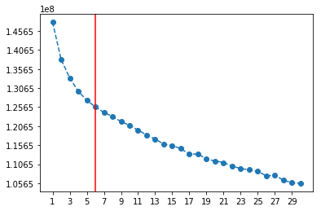

```python
plt.plot(kk, ss, linestyle='--', marker='o')
plt.xticks(np.arange(min(kk), max(kk)+1, 2.0))
plt.yticks(np.arange(min(ss), max(ss)+1, 5000000))
plt.axvline(x=6, color='red')
```

```python
# Re-fit the k-means model with the selected number of clusters and obtain
# cluster predictions for the general population demographics data.
km = KMeans(n_clusters=5)
km.fit(pcaed)
res = km.predict(pcaed)
```

```
<Container object of 5 artists>
```

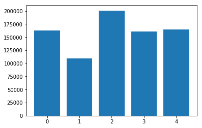

```python
values = np.unique(res, return_counts=True)
plt.bar(values[0], values[1])
```

### Discussion 3.1: Apply Clustering to General Population

I tried KMeans on different values of cluster up 30 sequantially and up to 60 with larger intervals between steps. First time I choose k equal 9, then to 7 and looked to see how does it apply to customer's data. It resulted in several cluster being uninformative and carrying small groups of respondents so I cut down number of cluster to 5 as it seen in first plot distance after 5 getting shorter and shorter and then remains almost the same. With 5 cluster distribuion over them looks more or less reasonable and in 3 clusters we are seeing roughly equal amount of data.

### Step 3.2: Apply All Steps to the Customer Data

Now that we have clusters and cluster centers for the general population, it's time to see how the customer data maps on to those clusters. We're going to use the fits from the general population to clean, transform, and cluster the customer data.

- Apply the same feature wrangling, selection, and engineering steps to the customer demographics using the `clean_data()` function created earlier.
- Carry the data through the feature scaling, PCA, and clustering steps, obtaining cluster assignments for all of the data in the customer demographics data.

Missing values in customers features are ALTER_HH_1 (1895-01-01 to 1899-12-31) and GEBAEUDETYP_5.0(company building w/o known company). Someone from demografic data was born 120 years ago and it is not a surprise that age missing among customers.

```python
def leveloff(train_df, test_df):
    diff = set(train_df) - set(test_df)
    feature_difference_df = pd.DataFrame(data=np.zeros((test_df.shape[0], len(diff))),
                                     columns=list(diff))
    test_df = test_df.join(feature_difference_df)
    return test_df
```

```python
# Apply preprocessing, feature transformation, and clustering from the general
# demographics onto the customer data, obtaining cluster predictions for the
# customer demographics data.
customers = clean_data(cleaner.customers, cleaner.summary)

customers_before = leveloff(cleaner.azdias, customers)

customers_after, fit_scaler, fit_imput = scale_and_impute(customers_before)

pcaed_customer = pca.transform(customers_after)
predict_customer = km.predict(pcaed_customer)
```

```
<Container object of 5 artists>
```

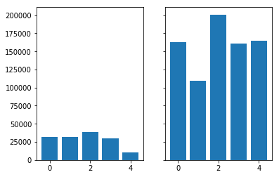

```python
cus_res = np.unique(predict_customer, return_counts=True)
fig, (ax1,ax2) = plt.subplots(1, 2, sharey=True)
ax1.bar(cus_res[0], cus_res[1])
ax2.bar(values[0], values[1])
```

### Step 3.3: Compare Customer Data to Demographics Data

At this point, I have clustered data based on demographics of the general population of Germany, and seen how the customer data for a mail-order sales company maps onto those demographic clusters. In this final substep, you will compare the two cluster distributions to see where the strongest customer base for the company is.

Consider the proportion of persons in each cluster for the general population, and the proportions for the customers. If we think the company's customer base to be universal, then the cluster assignment proportions should be fairly similar between the two. If there are only particular segments of the population that are interested in the company's products, then we should see a mismatch from one to the other. If there is a higher proportion of persons in a cluster for the customer data compared to the general population (e.g. 5% of persons are assigned to a cluster for the general population, but 15% of the customer data is closest to that cluster's centroid) then that suggests the people in that cluster to be a target audience for the company. On the other hand, the proportion of the data in a cluster being larger in the general population than the customer data (e.g. only 2% of customers closest to a population centroid that captures 6% of the data) suggests that group of persons to be outside of the target demographics.

- Compute the proportion of data points in each cluster for the general population and the customer data. (https://seaborn.pydata.org/generated/seaborn.barplot.html) function could be handy.
  - Recall the analysis you performed in step 1.1.3 of the project, where you separated out certain data points from the dataset if they had more than a specified threshold of missing values. If you found that this group was qualitatively different from the main bulk of the data, you should treat this as an additional data cluster in this analysis. Make sure that you account for the number of data points in this subset, for both the general population and customer datasets, when making your computations!
- Which cluster or clusters are overrepresented in the customer dataset compared to the general population? Select at least one such cluster and infer what kind of people might be represented by that cluster. Use the principal component interpretations from step 2.3 or look at additional components to help you make this inference. Alternatively, you can use the `.inverse_transform()` method of the PCA and StandardScaler objects to transform centroids back to the original data space and interpret the retrieved values directly.
- Perform a similar investigation for the underrepresented clusters. Which cluster or clusters are underrepresented in the customer dataset compared to the general population, and what kinds of people are typified by these clusters?

```python
combined_values = pd.DataFrame([values[1],cus_res[1]],index=[0,1], columns=values[0])
#combined_values['len'] = [values[1].sum(), cus_res[1].sum()]
combined_values['type'] = ['demographic', 'customer']
melted_values = pd.melt(combined_values, id_vars='type', var_name="cluster", value_name="count")
in1 = melted_values[melted_values['type'] == 'demographic']['count'] / values[1].sum() * 100
in2 = melted_values[melted_values['type'] == 'customer']['count'] / cus_res[1].sum() * 100
melted_values.loc[in1.index, 'fraction'] = in1
melted_values.loc[in2.index, 'fraction'] = in2
```

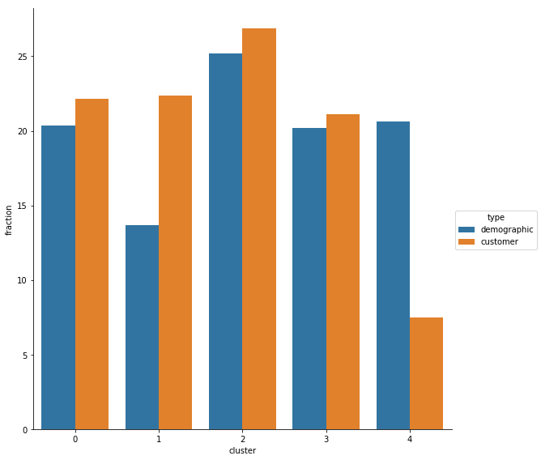

```python
# Compare the proportion of data in each cluster for the customer data to the
# proportion of data in each cluster for the general population.
sns.factorplot(data=melted_values, x='cluster',y='fraction', hue='type', kind='bar', size=8)
```

We have identified **5 clusters and 3 scenarios** where people in cluster overrepresented, underrepresented and more or less equal.  
Higher proportion of persons in a cluster for the customer data compared to the general population : cluster 1. The proportion of the data in a cluster being larger in the general population than the customer data: cluster 4. More or less equal: clusters **0, 2, 3**. And since our data split up to 2 pieces < 34 > of missing features and found out that distribution of those sets looked differently this should be analized as separate set. In steps below we will be looking in part of data where less than 34 features where missing in each row.

```python
def plot_pc(axis, df):
    n=0
    for i,v in enumerate(ax):
        for j, v in enumerate(ax[i]):
            sns.barplot(x=list(df[n][0]), y=list(df[n][1]), ax=ax[i][j]).set_title(df.index[n])
            n+=1
```

```python
pca1 = ['income_0', 'HH_EINKOMMEN_SCORE', 'PLZ8_ANTG4',
        'PLZ8_ANTG3', 'LP_STATUS_GROB_1.0','FINANZ_MINIMALIST',
        'PLZ8_ANTG1', 'MOBI_REGIO', 'KBA05_GBZ', 'KBA05_ANTG1']

pca_mix = ['ALTERSKATEGORIE_GROB',
           'decade_6.0',
           'ZABEOTYP_3.0',
           'ANREDE_KZ',
           'SEMIO_VERT',
           'FINANZ_VORSORGER',
           'FINANZ_SPARER',
           'SEMIO_FAM',
           'SEMIO_REL',
           'SEMIO_KAEM']
```

```python
# What kinds of people are part of a cluster that is overrepresented in the
# customer data compared to the general population?

over_r_2 = customers_before[predict_customer==1]
over_r_2[pca1].describe()
```

|  | income_0 | HH_EINKOMMEN_SCORE | PLZ8_ANTG4 | PLZ8_ANTG3 | LP_STATUS_GROB_1.0 | FINANZ_MINIMALIST | PLZ8_ANTG1 | MOBI_REGIO | KBA05_GBZ | KBA05_ANTG1 |
| --- | --- | --- | --- | --- | --- | --- | --- | --- | --- | --- |
| count | 31740.0 | 31740.000000 | 31542.000000 | 31542.000000 | 31740.0 | 31740.000000 | 31542.000000 | 31398.000000 | 31398.000000 | 31398.000000 |
| mean | 0.0 | 1.799433 | 0.398770 | 1.214222 | 0.0 | 4.924575 | 2.866432 | 4.335181 | 4.145264 | 3.080578 |
| std | 0.0 | 0.984059 | 0.503759 | 0.689881 | 0.0 | 0.278934 | 0.744026 | 0.717260 | 0.731634 | 0.908569 |
| min | 0.0 | 1.000000 | 0.000000 | 0.000000 | 0.0 | 2.000000 | 1.000000 | 1.000000 | 1.000000 | 0.000000 |
| 25% | 0.0 | 1.000000 | 0.000000 | 1.000000 | 0.0 | 5.000000 | 2.000000 | 4.000000 | 4.000000 | 2.000000 |
| 50% | 0.0 | 1.000000 | 0.000000 | 1.000000 | 0.0 | 5.000000 | 3.000000 | 4.000000 | 4.000000 | 3.000000 |
| 75% | 0.0 | 2.000000 | 1.000000 | 2.000000 | 0.0 | 5.000000 | 3.000000 | 5.000000 | 5.000000 | 4.000000 |
| max | 0.0 | 6.000000 | 2.000000 | 3.000000 | 0.0 | 5.000000 | 4.000000 | 6.000000 | 5.000000 | 4.000000 |

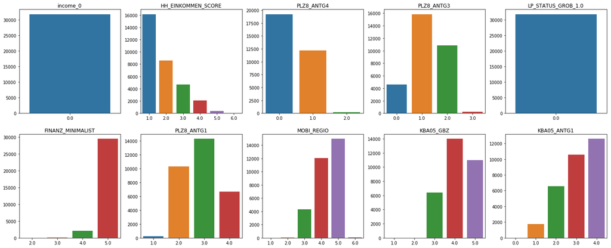

```python
df = over_r_2[pca1].apply(np.unique, return_counts=True)
fg, ax = plt.subplots(2,5, figsize=(25,10))
plot_pc(ax, df)
```

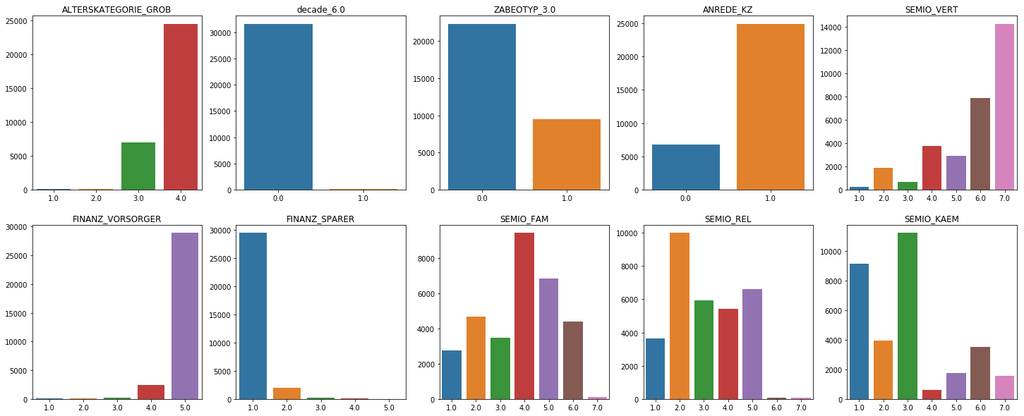

```python
df = over_r_2[pca_mix].apply(np.unique, return_counts=True)
fg, ax = plt.subplots(2,5, figsize=(25,10))
plot_pc(ax, df)
```

Looks like this cluster describes people with low personal and huge overall household income, who could that be? Well maybe women (housewife) or grown kids. This cluster is low movers, potentially leaving in their houses. Worth noting estimated age which is > 60 and gender - male. So those could be potential targets for campaign. Group size over 30k.

```python
# What kinds of people are part of a cluster that is underrepresented in the
# customer data compared to the general population?
under_r_0 = customers_before[predict_customer==4]
under_r_0[pca1].describe()
```

|  | income_0 | HH_EINKOMMEN_SCORE | PLZ8_ANTG4 | PLZ8_ANTG3 | LP_STATUS_GROB_1.0 | FINANZ_MINIMALIST | PLZ8_ANTG1 | MOBI_REGIO | KBA05_GBZ | KBA05_ANTG1 |
| --- | --- | --- | --- | --- | --- | --- | --- | --- | --- | --- |
| count | 10593.000000 | 10593.000000 | 10305.000000 | 10305.000000 | 10593.000000 | 10593.000000 | 10305.000000 | 10059.000000 | 10059.000000 | 10059.000000 |
| mean | 0.472199 | 4.732087 | 1.117128 | 2.197186 | 0.534598 | 2.758331 | 1.712664 | 2.198628 | 2.500547 | 0.744507 |
| std | 0.499250 | 1.204131 | 0.673911 | 0.734263 | 0.498825 | 1.113945 | 0.747680 | 1.067476 | 1.143456 | 0.994386 |
| min | 0.000000 | 1.000000 | 0.000000 | 0.000000 | 0.000000 | 1.000000 | 0.000000 | 1.000000 | 1.000000 | 0.000000 |
| 25% | 0.000000 | 4.000000 | 1.000000 | 2.000000 | 0.000000 | 2.000000 | 1.000000 | 1.000000 | 2.000000 | 0.000000 |
| 50% | 0.000000 | 5.000000 | 1.000000 | 2.000000 | 1.000000 | 3.000000 | 2.000000 | 2.000000 | 2.000000 | 0.000000 |
| 75% | 1.000000 | 6.000000 | 2.000000 | 3.000000 | 1.000000 | 3.000000 | 2.000000 | 3.000000 | 3.000000 | 1.000000 |
| max | 1.000000 | 6.000000 | 2.000000 | 3.000000 | 1.000000 | 5.000000 | 4.000000 | 6.000000 | 5.000000 | 4.000000 |

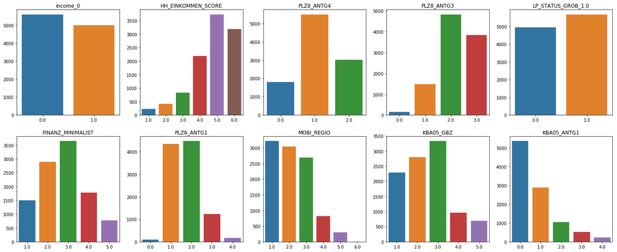

```python
df2 = under_r_0[pca1].apply(np.unique, return_counts=True)
fg, ax = plt.subplots(2,5, figsize=(25,10))
plot_pc(ax, df2)
```

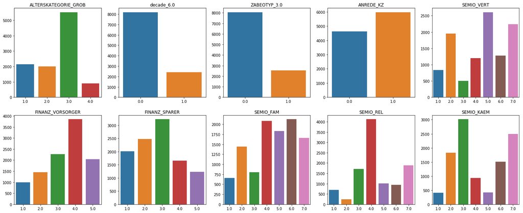

```python
df2 = under_r_0[pca_mix].apply(np.unique, return_counts=True)
fg, ax = plt.subplots(2,5, figsize=(25,10))
plot_pc(ax, df2)
```

So this is unlike previous group got very low personal and household eranings. Also group belongs to frequent movers. Estimated age is between 45-60. ~half of respondents are female. Group size over 10k. There are differencies in types and persnalities but I dont have full encoding of those.

```python
# More like real customers
equal = customers_before[predict_customer==2]
df3 = equal[pca1].apply(np.unique, return_counts=True)
equal[pca1].describe()
```

|  | income_0 | HH_EINKOMMEN_SCORE | PLZ8_ANTG4 | PLZ8_ANTG3 | LP_STATUS_GROB_1.0 | FINANZ_MINIMALIST | PLZ8_ANTG1 | MOBI_REGIO | KBA05_GBZ | KBA05_ANTG1 |
| --- | --- | --- | --- | --- | --- | --- | --- | --- | --- | --- |
| count | 38137.000000 | 38137.000000 | 37502.000000 | 37502.000000 | 38137.000000 | 38137.000000 | 37502.000000 | 37292.000000 | 37290.000000 | 37292.000000 |
| mean | 0.315442 | 4.542623 | 0.997893 | 2.086449 | 0.349975 | 3.539712 | 1.831262 | 2.436582 | 2.690265 | 0.992009 |
| std | 0.464698 | 1.337296 | 0.638215 | 0.712914 | 0.476968 | 0.981902 | 0.736834 | 1.151627 | 1.177900 | 1.146219 |
| min | 0.000000 | 1.000000 | 0.000000 | 0.000000 | 0.000000 | 1.000000 | 0.000000 | 1.000000 | 1.000000 | 0.000000 |
| 25% | 0.000000 | 4.000000 | 1.000000 | 2.000000 | 0.000000 | 3.000000 | 1.000000 | 1.000000 | 2.000000 | 0.000000 |
| 50% | 0.000000 | 5.000000 | 1.000000 | 2.000000 | 0.000000 | 4.000000 | 2.000000 | 2.000000 | 3.000000 | 1.000000 |
| 75% | 1.000000 | 6.000000 | 1.000000 | 3.000000 | 1.000000 | 4.000000 | 2.000000 | 3.000000 | 3.000000 | 2.000000 |
| max | 1.000000 | 6.000000 | 2.000000 | 3.000000 | 1.000000 | 5.000000 | 4.000000 | 6.000000 | 5.000000 | 4.000000 |

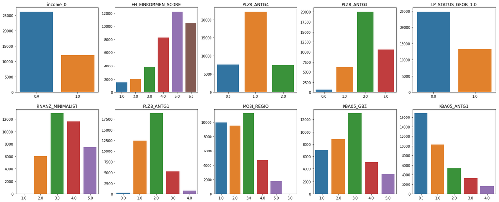

```python
fg, ax = plt.subplots(2,5, figsize=(25,10))
plot_pc(ax, df3)
```

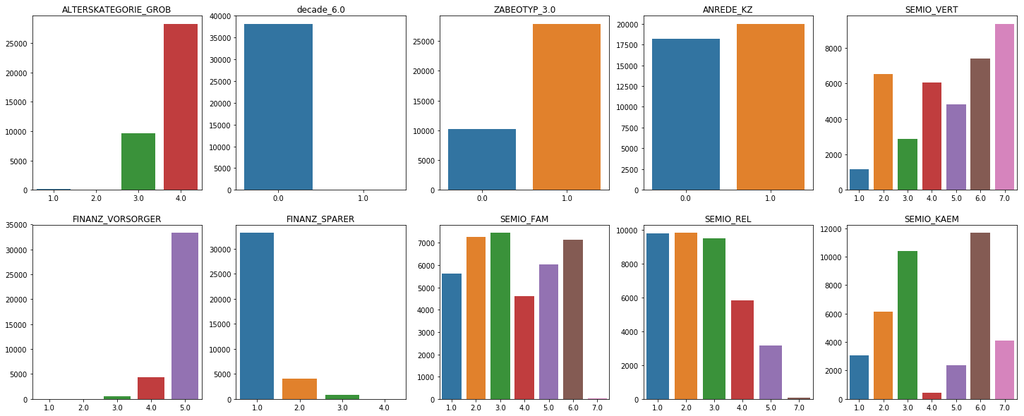

```python
df3 = equal[pca_mix].apply(np.unique, return_counts=True)
fg, ax = plt.subplots(2,5, figsize=(25,10))
plot_pc(ax, df3)
```

The closest cluster consists of persons >60 years old, the proportion of male and female is almost equal, group still has low personal income and more households with rather low earnings compared to 1 cluster.

### Discussion 3.3: Compare Customer Data to Demographics Data

Current point of interest:

Would be nice to get full explanation of these codes as FINANZ_MINIMALIST, FINANZ_SPARER,FINANZ_VORSORGER and so on to understand better people behinf clusters.